*Ivan Efremov*

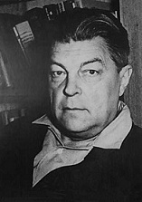

The study of dinosaurs roughly began in the mid-1800s, when the English paleontologist Richard Owen coined the term “dinosaur”. People had been discovering dinosaurs for some time before then, starting all the way back in 1676 with Megalosaurus. Yet, the study of how dinosaurs took the first steps in getting into the hands of paleontologists did not begin until 1940, when the Soviet paleontologist Ivan Yefremov (also spelled Yefremov) coined the term “taphonomy”, which literally means “the laws of burial”. Efremov originally wrote the first book on the topic in 1943, but publication was delayed until 1950 because of World War II.

Titled “Taphonomy”, Efremov analyzed the processes of destruction and preservation of continental sediments through time, as well as how they could improve understanding of the deposits of fossilized organisms. He also presented methods for examining the transference of biological materials from living populations to their foundation in sedimentary deposits, calling the process the “heart of taphonomic study”. Further, Efremov preached a dialectical (opposite) view of taphonomy, balancing both the study of erosional areas where life existed and the depositional areas where remains accumulated.

Yet, Efremov specialized in terrestrial vertebrates, paying much less attention to marine deposits and marine invertebrates. As such, only his broad methods of taphonomy generalized to aquatic creatures and environments. In fact, terrestrial and marine studies of taphonomy started out fairly independent of one another, creating an odd gap between practitioners of either field in the 1960s. Efremov even expressed displeasure with the studies of marine paleontologists during this time. However, the decade also marked paleontologists’ embrace of taphonomy as a formal field, with some applying Efremov’s methods and others inventing their own.